# Project 3 Diabetes

```python
import matplotlib as mpl
import matplotlib.pyplot as plt

import pandas as pd
import scipy.stats
from scipy import stats

import numpy as np
```

This Kaggle dataset contains the statistics of 2000 patients and their vitals. The columns include

Pregnancies - Number of times pregnant

Glucose - Plasma glucose concentration a 2 hours in an oral glucose tolerance test

BloodPressure - Diastolic blood pressure (mm Hg)

SkinThickness - Triceps skin fold thickness (mm)

Insulin - 2-Hour serum insulin (mu U/ml)

BMI - Body mass index (weight in kg/(height in m)^2)

DiabetesPedigreeFunction - Diabetes pedigree function

Age - Age (years)

Outcome - Class variable (0 or 1) class value 1 is interpreted as "tested positive for diabetes

In this project, I use logistic regression on Blood Pressure and Glucose and see how much it affects the Outcome variable.

```python
#read in csv file
diabetes= pd.read_csv('diabetes.csv')
```

```python
diabetes.describe()
```

|  | Pregnancies | Glucose | BloodPressure | SkinThickness | Insulin | BMI | DiabetesPedigreeFunction | Age | Outcome |
| --- | --- | --- | --- | --- | --- | --- | --- | --- | --- |
| count | 2000.000000 | 2000.000000 | 2000.000000 | 2000.000000 | 2000.000000 | 2000.000000 | 2000.000000 | 2000.000000 | 2000.000000 |
| mean | 3.703500 | 121.182500 | 69.145500 | 20.935000 | 80.254000 | 32.193000 | 0.470930 | 33.090500 | 0.342000 |
| std | 3.306063 | 32.068636 | 19.188315 | 16.103243 | 111.180534 | 8.149901 | 0.323553 | 11.786423 | 0.474498 |
| min | 0.000000 | 0.000000 | 0.000000 | 0.000000 | 0.000000 | 0.000000 | 0.078000 | 21.000000 | 0.000000 |
| 25% | 1.000000 | 99.000000 | 63.500000 | 0.000000 | 0.000000 | 27.375000 | 0.244000 | 24.000000 | 0.000000 |
| 50% | 3.000000 | 117.000000 | 72.000000 | 23.000000 | 40.000000 | 32.300000 | 0.376000 | 29.000000 | 0.000000 |
| 75% | 6.000000 | 141.000000 | 80.000000 | 32.000000 | 130.000000 | 36.800000 | 0.624000 | 40.000000 | 1.000000 |
| max | 17.000000 | 199.000000 | 122.000000 | 110.000000 | 744.000000 | 80.600000 | 2.420000 | 81.000000 | 1.000000 |

```python
diabetes.head()
```

|  | Pregnancies | Glucose | BloodPressure | SkinThickness | Insulin | BMI | DiabetesPedigreeFunction | Age | Outcome |
| --- | --- | --- | --- | --- | --- | --- | --- | --- | --- |
| 0 | 2 | 138 | 62 | 35 | 0 | 33.6 | 0.127 | 47 | 1 |
| 1 | 0 | 84 | 82 | 31 | 125 | 38.2 | 0.233 | 23 | 0 |
| 2 | 0 | 145 | 0 | 0 | 0 | 44.2 | 0.630 | 31 | 1 |
| 3 | 0 | 135 | 68 | 42 | 250 | 42.3 | 0.365 | 24 | 1 |
| 4 | 1 | 139 | 62 | 41 | 480 | 40.7 | 0.536 | 21 | 0 |

```python
#2000 rows, 9 columns
diabetes.shape
```

```
(2000, 9)
```

```python
# separate the independent variables and dependent variables
# The independent variables are:Glucose, blood pressure
# The dependent variable is: Outcome

X = diabetes.iloc[:, [1,2]].values
y = diabetes.iloc[:,8].values
```

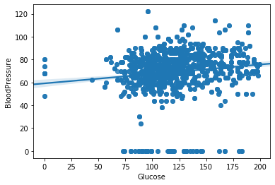

```python
#scatter plot of Glucose vs. Blood Pressure
import seaborn as sns
sns.regplot(diabetes.Glucose,diabetes.BloodPressure)
```

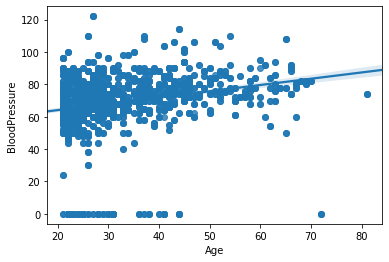

```python
sns.regplot(diabetes.Age,diabetes.BloodPressure)
```

```python
import sklearn as scikit_learn

from sklearn.model_selection import train_test_split
```

```python
# Splitting the dataset into the Training set and Test set

X_train, X_test, y_train, y_test = train_test_split(X, y, test_size = 0.2, random_state = 0)
```

```python
X_train.shape,y_train.shape
```

```
((1600, 2), (1600,))
```

```python
X_test.shape,y_test.shape
```

```
((400, 2), (400,))
```

```python
from sklearn.preprocessing import StandardScaler
sc_X = StandardScaler()
X_train = sc_X.fit_transform(X_train)
X_test = sc_X.transform(X_test)
```

```python
X_train
```

```
array([[-0.01485297,  0.466638  ],
       [ 1.29329836,  0.16097992],
       [-0.60663571,  0.26286595],
       ...,
       [-0.82466093, -0.24656419],
       [-1.13612553,  0.26286595],
       [ 0.45234393,  0.67041006]])
```

```python
X_test
```

[output not shown]

[output cut: 345 more lines]

[output not shown]

```python
#fit logistical regression to training set
from sklearn.linear_model import LogisticRegression
```

```python
classifier = LogisticRegression(solver='lbfgs')
classifier.fit(X_train,y_train)
```

```
LogisticRegression(C=1.0, class_weight=None, dual=False, fit_intercept=True,
                   intercept_scaling=1, l1_ratio=None, max_iter=100,
                   multi_class='warn', n_jobs=None, penalty='l2',
                   random_state=None, solver='lbfgs', tol=0.0001, verbose=0,
                   warm_start=False)
```

```python
y_pred = classifier.predict(X_test)
y_pred
```

```
array([0, 0, 1, 0, 1, 0, 0, 0, 0, 0, 0, 1, 0, 0, 0, 0, 0, 0, 0, 1, 0, 0,
       0, 0, 0, 1, 0, 1, 0, 1, 0, 0, 0, 1, 0, 1, 1, 0, 0, 0, 0, 0, 1, 1,
       0, 0, 1, 0, 1, 0, 0, 0, 0, 1, 0, 0, 0, 0, 0, 0, 0, 0, 0, 1, 0, 0,
       0, 0, 1, 0, 0, 0, 0, 0, 0, 1, 0, 0, 0, 0, 0, 1, 0, 1, 0, 0, 0, 1,
       1, 0, 1, 0, 1, 0, 1, 0, 0, 0, 0, 0, 0, 1, 0, 1, 0, 0, 0, 1, 0, 1,
       0, 1, 0, 0, 0, 0, 1, 0, 1, 0, 1, 0, 0, 0, 0, 0, 0, 1, 0, 0, 0, 0,
       0, 1, 0, 0, 0, 0, 0, 0, 0, 0, 0, 0, 0, 0, 1, 0, 1, 0, 0, 0, 1, 0,
       0, 0, 0, 0, 0, 1, 0, 0, 0, 0, 0, 0, 0, 0, 0, 0, 0, 0, 0, 0, 0, 0,
       0, 0, 0, 0, 0, 0, 0, 0, 0, 1, 0, 1, 0, 0, 0, 0, 1, 0, 0, 0, 1, 0,
       0, 0, 1, 1, 0, 0, 0, 0, 0, 0, 0, 0, 1, 1, 0, 0, 1, 0, 0, 1, 0, 0,
       0, 0, 0, 0, 0, 0, 0, 1, 0, 1, 0, 0, 0, 0, 0, 0, 0, 1, 0, 0, 0, 0,
       0, 0, 0, 0, 1, 0, 0, 1, 0, 0, 0, 1, 0, 0, 1, 0, 0, 1, 0, 0, 0, 0,
       0, 1, 1, 0, 0, 0, 0, 1, 0, 0, 1, 1, 0, 0, 1, 0, 0, 0, 0, 1, 1, 0,
       0, 0, 1, 0, 0, 1, 0, 0, 0, 0, 0, 0, 0, 0, 1, 0, 0, 0, 0, 0, 0, 0,
       0, 0, 0, 0, 0, 0, 0, 0, 1, 1, 0, 0, 0, 0, 1, 1, 0, 1, 0, 0, 0, 0,
       0, 0, 0, 0, 1, 0, 1, 0, 1, 1, 0, 1, 0, 1, 1, 0, 0, 0, 0, 0, 1, 0,
       0, 1, 0, 1, 0, 0, 0, 0, 0, 0, 0, 0, 0, 0, 0, 0, 0, 0, 0, 0, 0, 1,
       0, 0, 0, 1, 0, 0, 0, 0, 0, 0, 0, 0, 0, 0, 0, 0, 0, 0, 0, 0, 0, 0,
       1, 1, 1, 0], dtype=int64)
```

```python
# confusion matrix
from sklearn.metrics import confusion_matrix
```

```python
confusion_mx = confusion_matrix(y_test,y_pred)
```

```python
confusion_mx
```

```
array([[245,  27],
       [ 67,  61]], dtype=int64)
```

False positive: 27

False negative: 67

```python
classifier.score(X_test,y_test)
```

```
0.765
```

Accuracy of predictor is around 77 percent, decently accurate

```python
print( 'The Predicted class %s, The Real class %s' % (classifier.predict(X).reshape(1,-1), y ))
print( 'The probabilities for each class from 0 to 2: %s' % (classifier.predict_proba(X).reshape(1,-1)))
```

```
The Predicted class [[1 1 1 ... 1 1 1]], The Real class [1 0 1 ... 0 1 0]
The probabilities for each class from 0 to 2: [[0. 1. 0. ... 1. 0. 1.]]
```

```python
# The Probability of diabetes for each data points

classifier.predict_proba(X_test )
```

[output not shown]

[output cut: 345 more lines]

[output not shown]

```python
from sklearn.multiclass import OneVsRestClassifier, OneVsOneClassifier
OneVsRest = OneVsRestClassifier(classifier).fit(X_train,y_train)
OneVsOne = OneVsOneClassifier(classifier).fit(X_train,y_train)
print( 'One vs rest accuracy: %.3f' % OneVsRest.score(X_test,y_test) )
print( 'One vs one accuracy: %.3f' % OneVsOne.score(X_test,y_test) )
```

```
One vs rest accuracy: 0.765
One vs one accuracy: 0.765
```

```python
#Visualization
import seaborn as sns
```

```python
from matplotlib.colors import ListedColormap
```

[output not shown]

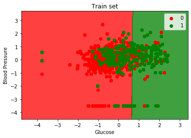

```python
# train dataset
X_set, y_set = X_train, y_train
X1, X2 = np.meshgrid(np.arange(start = X_set[:, 0].min() - 1, stop = X_set[:, 0].max() + 1, step = 0.01),
                     np.arange(start = X_set[:, 1].min() - 1, stop = X_set[:, 1].max() + 1, step = 0.01))
plt.contourf(X1, X2, classifier.predict(np.array([X1.ravel(), X2.ravel()]).T).reshape(X1.shape),
             alpha = 0.75, cmap = ListedColormap(('red', 'green')))
plt.xlim(X1.min(), X1.max())
plt.ylim(X2.min(), X2.max())
for i, j in enumerate(np.unique(y_set)):
    plt.scatter(X_set[y_set == j, 0], X_set[y_set == j, 1],
                c = ListedColormap(('red', 'green'))(i), label = j)
plt.title('Train set')
plt.xlabel('Glucose')
plt.ylabel('Blood Pressure')
plt.legend()
plt.show()
```

[output not shown]

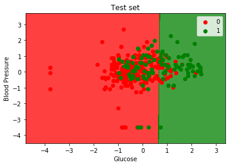

```python
# test dataset
X_set, y_set = X_test, y_test
X1, X2 = np.meshgrid(np.arange(start = X_set[:, 0].min() - 1, stop = X_set[:, 0].max() + 1, step = 0.01),
                     np.arange(start = X_set[:, 1].min() - 1, stop = X_set[:, 1].max() + 1, step = 0.01))
plt.contourf(X1, X2, classifier.predict(np.array([X1.ravel(), X2.ravel()]).T).reshape(X1.shape),
             alpha = 0.75, cmap = ListedColormap(('red', 'green')))
plt.xlim(X1.min(), X1.max())
plt.ylim(X2.min(), X2.max())
for i, j in enumerate(np.unique(y_set)):
    plt.scatter(X_set[y_set == j, 0], X_set[y_set == j, 1],
                c = ListedColormap(('red', 'green'))(i), label = j)
plt.title('Test set')
plt.xlabel('Glucose')
plt.ylabel('Blood Pressure')
plt.legend()
plt.show()
```